# HomeWork 4

Bronson Bagwell

2024-01-31

```r
library(party)
library(caret)
library(randomForest)
```

```r
data <- read.csv("GraduateAdmission.csv")
data <- subset(data, select = -Serial.No.)

str(data)
names(data)
```

[output not shown]

# 1. Prepare the data by converting some of the features to factors.

```r
data$UnivRating <- as.factor(data$UnivRating)
data$Research <- as.factor(data$Research)
data$Admit <- as.factor(data$Admit)
```

# 2. Split the data into a 80% training set and a 20% test set. Use set.seed (7332.01) for reproducibility.

```r
set.seed(7332.01)
Index <- createDataPartition(data$Admit,p=0.8,list=FALSE)
trdata <- data[Index,]
tsdata <- data[-Index,]
head(trdata)
```

```
##   GRE TOEFL UnivRating SOP LOR CGPA Research Admit
## 2 324   107          4 4.0 4.5 8.87        1     1
## 3 316   104          3 3.0 3.5 8.00        1     1
## 4 322   110          3 3.5 2.5 8.67        1     1
## 5 314   103          2 2.0 3.0 8.21        0     1
## 6 330   115          5 4.5 3.0 9.34        1     1
## 7 321   109          3 3.0 4.0 8.20        1     1
```

```r
head(tsdata)
```

```
##    GRE TOEFL UnivRating SOP LOR CGPA Research Admit
## 1  337   118          4 4.5 4.5 9.65        1     1
## 14 307   109          3 4.0 3.0 8.00        1     0
## 22 325   114          4 3.0 2.0 8.40        0     1
## 26 340   120          5 4.5 4.5 9.60        1     1
## 29 295    93          1 2.0 2.0 7.20        0     0
## 33 338   118          4 3.0 4.5 9.40        1     1
```

```r
names(data)
```

```
## [1] "GRE"        "TOEFL"      "UnivRating" "SOP"        "LOR"
## [6] "CGPA"       "Research"   "Admit"
```

# 3. Fit Classification Tree to the training dataset and answer the following questions.

```r
clatree <- ctree(Admit~.,trdata)
print(clatree)
```

```
##
##   Conditional inference tree with 4 terminal nodes
##
## Response:  Admit
## Inputs:  GRE, TOEFL, UnivRating, SOP, LOR, CGPA, Research
## Number of observations:  320
##
## 1) CGPA <= 8.03; criterion = 1, statistic = 111.52
##   2) LOR <= 2.5; criterion = 0.998, statistic = 13.314
##     3)*  weights = 37
##   2) LOR > 2.5
##     4)*  weights = 23
## 1) CGPA > 8.03
##   5) CGPA <= 8.5; criterion = 1, statistic = 30.024
##     6)*  weights = 84
##   5) CGPA > 8.5
##     7)*  weights = 176
```

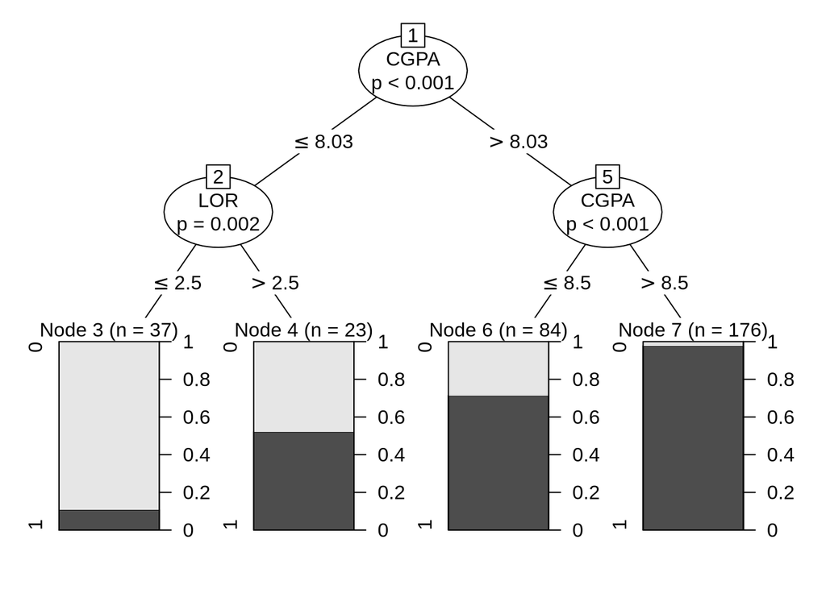

```r
    # Plot the classification tree and interpret the results.

plot(clatree)
```

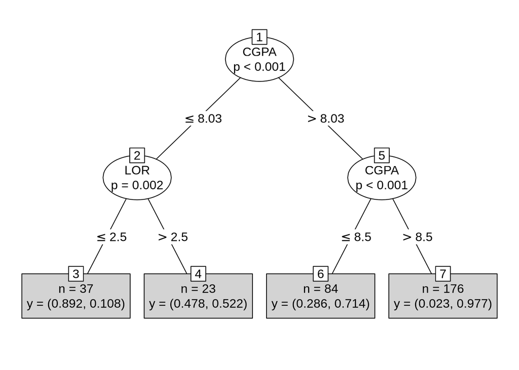

```r
plot(clatree,type="simple")
```

Interpret

This conditional inference tree predicts admission outcomes based on seven input features (GRE, TOEFL, UnivRating, SOP, LOR, CGPA, Research) with 320 observations. The primary split is on CGPA at 8.03. For CGPA ≤ 8.03, it considers LOR, splitting at 2.5, resulting in two terminal nodes. For CGPA > 8.03, it further splits on CGPA at 8.5, creating two more terminal nodes. The model predicts “Admit” with specific sample sizes in each terminal node.

```r
    #Predict the response on the test data, and produce a confusion matrix comparing the test labels to the predicted test labels. What is the test overall accuracy. misclassification (error rate), sensitivity and specificity?

pred_clatree <-predict(clatree, tsdata)
conf_clatree<-table(Predicted=pred_clatree,Actual=tsdata$Admit)
conf_clatree
```

```
##          Actual
## Predicted  0  1
##         0  7  0
##         1 11 62
```

```r
    #Accuracy
Accuracy <- sum(diag(conf_clatree))/sum(conf_clatree)
Accuracy
```

```
## [1] 0.8625
```

```r
    #Misclassification (Error Rate)
test_ercltree <- 1-sum(diag(conf_clatree))/sum(conf_clatree )
test_ercltree
```

```
## [1] 0.1375
```

```r
    #Sensitivity and Specificity
cm_clatree <- caret::confusionMatrix(pred_clatree, factor(tsdata$Admit), positive = "1")
cm_clatree$byClass["Sensitivity"]
```

```
## Sensitivity
##           1
```

```r
cm_clatree$byClass["Specificity"]
```

```
## Specificity
##   0.3888889
```

# 4. Fit random forests for classification to the training data and answer the following questions.

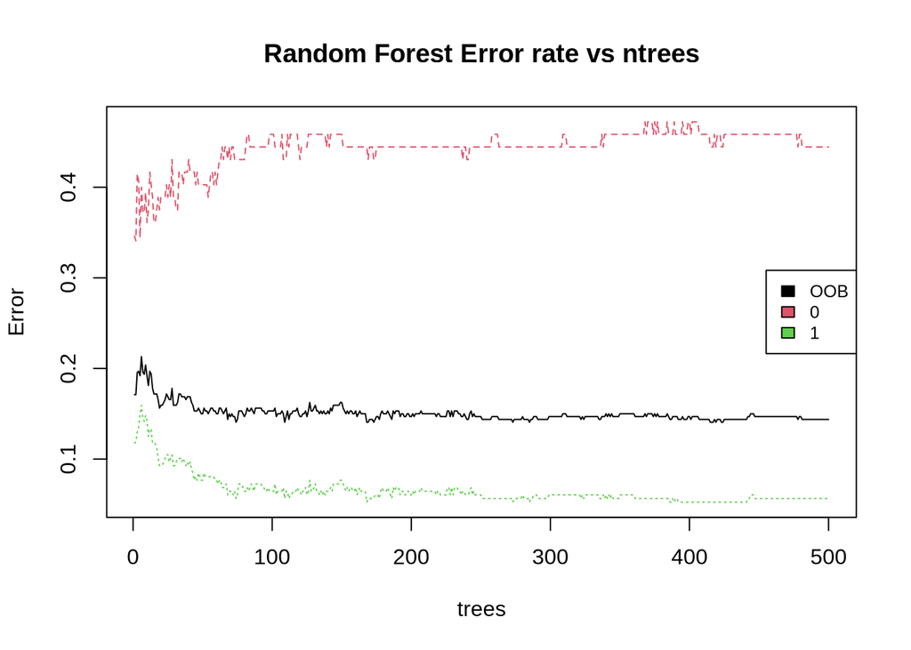

```r
clarf <- randomForest(Admit~.,trdata,importance=TRUE)

    #Plot the random forest. Describe the plot.
plot(clarf,main="Random Forest Error rate vs ntrees" )
legend("right",colnames(clarf$err.rate),col=1:3,cex=0.8,fill=1:3)
```

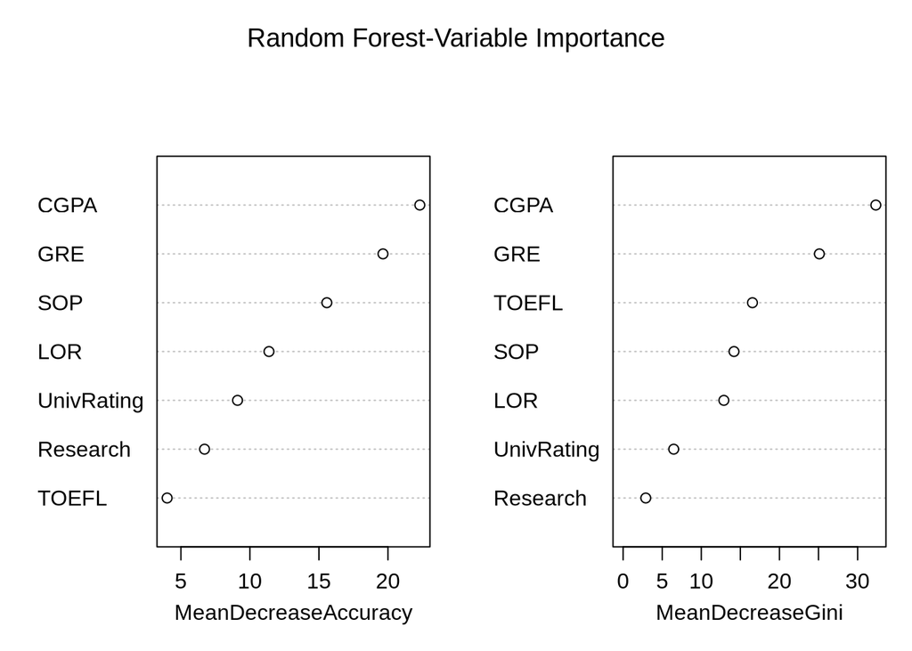

```r
    #Use varImpPlot() function to determine which variables are most important. List the top 3 important features.
varImpPlot(clarf,main="Random Forest-Variable Importance" )
```

```r
importance(clarf)
```

```
##                    0          1 MeanDecreaseAccuracy MeanDecreaseGini
## GRE        15.695736 11.9717633            19.640415        25.105862
## TOEFL       4.645997  0.9293614             4.002182        16.546235
## UnivRating  6.122275  7.1812629             9.103327         6.472561
## SOP        10.536632 11.2777500            15.572812        14.186140
## LOR        17.818587 -3.1347017            11.381037        12.887639
## CGPA       24.129922  6.9841060            22.310352        32.331959
## Research    2.371904  5.9945258             6.712365         2.896159
```

Describe the plot

This is a plot describing Error vs ntrees. Out of bag Error is relativly Steady. As ntrees increases Non-Admit error rate increases and then levels out at around ntrees=100. As ntrees increases Admit error rate decreases and then levels out at around ntrees=180.

Top 3 important features by MeanDecreaseAccuracy

1. CGPA
2. GRE
3. SOP

```r
    #Predict the response on the test data, and produce a confusion matrix comparing the test labels to the predicted test labels. What is the test overall accuracy and misclassification (error rate), sensitivity and specificity?
pred_clarf  <-predict(clarf , tsdata)
conf_clarf <-table(Predicted=pred_clarf ,Actual=tsdata$Admit)
conf_clarf
```

```
##          Actual
## Predicted  0  1
##         0 11  5
##         1  7 57
```

```r
    #Accuracy
Accuracy <- sum(diag(conf_clarf))/sum(conf_clarf)
Accuracy
```

```
## [1] 0.85
```

```r
    #Misclassification (Error Rate)
test_erclarf <- 1-sum(diag(conf_clarf ))/sum(conf_clarf )
test_erclarf
```

```
## [1] 0.15
```

```r
    #Sensitivity and Specificity
cm_clarf <- caret::confusionMatrix(pred_clarf, factor(tsdata$Admit), positive = "1")
cm_clarf$byClass["Sensitivity"]
```

```
## Sensitivity
##   0.9193548
```

```r
cm_clarf$byClass["Specificity"]
```

```
## Specificity
##   0.6111111
```

# 5. Fit Bagging for classification to the training data and answer the following questions

```r
clabag <- randomForest(Admit ~ ., trdata, mtry = ncol(trdata) - 1, importance = TRUE)  # bagging = use all predictors
print(clabag)
```

```
##
## Call:
##  randomForest(formula = Admit ~ ., data = trdata, mtry = ncol(trdata) -      1, importance = TRUE)
##                Type of random forest: classification
##                      Number of trees: 500
## No. of variables tried at each split: 7
##
##         OOB estimate of  error rate: 15%
## Confusion matrix:
##    0   1 class.error
## 0 39  33  0.45833333
## 1 15 233  0.06048387
```

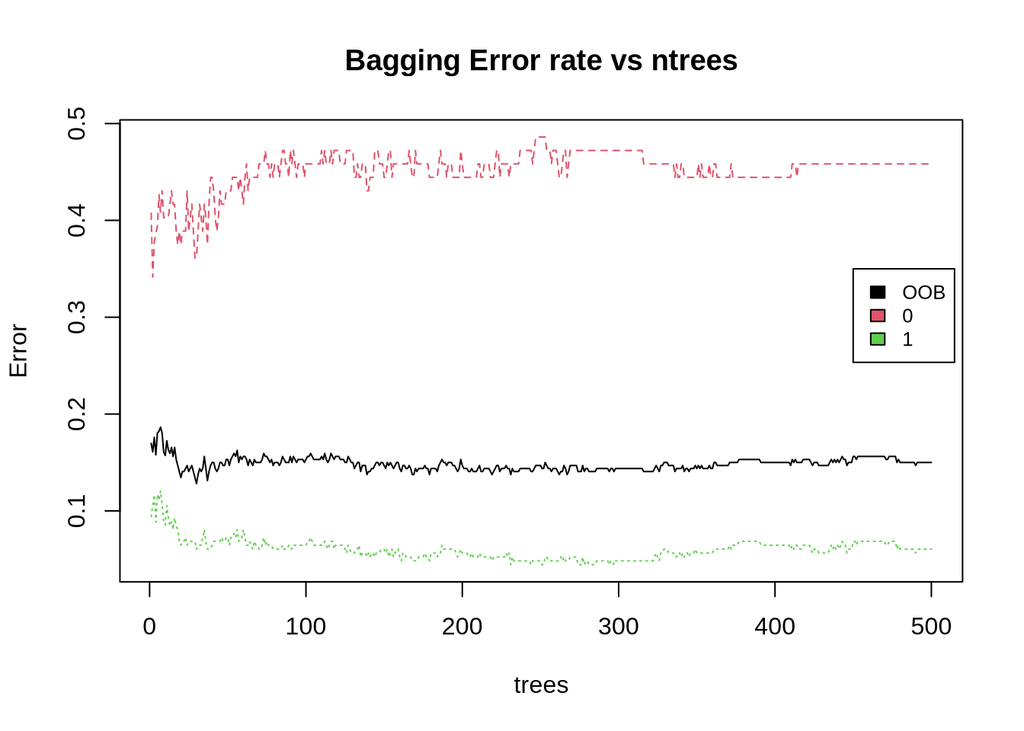

```r
    #Plot the Bagging model. Describe the plot.
plot(clabag,main="Bagging Error rate vs ntrees")
legend(450,0.35,colnames(clarf$err.rate),col=1:3,cex=0.8,fill=1:3)
```

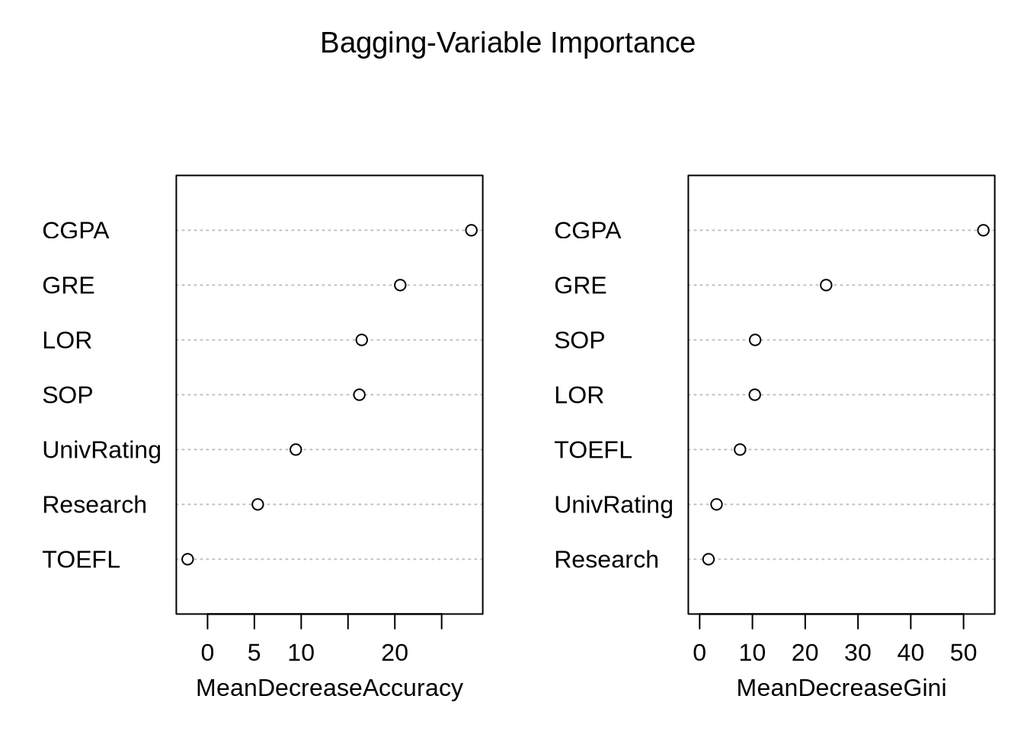

```r
    #Use the varImpPlot() function to determine which variables are most important.
varImpPlot(clabag, main="Bagging-Variable Importance ")
```

```r
importance(clabag)
```

```
##                     0         1 MeanDecreaseAccuracy MeanDecreaseGini
## GRE        16.4164824 11.019742            20.577435        23.966239
## TOEFL       2.3412964 -4.272555            -2.124879         7.655218
## UnivRating  3.9692013  8.205300             9.424996         3.201128
## SOP        12.8750116  8.757889            16.213018        10.510788
## LOR        24.4751247 -4.216866            16.466996        10.448372
## CGPA       37.8907783  6.786666            28.176145        53.758996
## Research   -0.5499326  5.727067             5.365743         1.681335
```

Describe the plot

This is a plot describing Error vs ntrees. Out of bag Error is relativly Steady with a slight decrease as ntrees increases. As ntrees increases Non-Admit error rate slightly increases and then levels. As ntrees increases Admit error rate is decreases then levels out at around ntrees=90

Top 3 important features by MeanDecreaseAccuracy

1. CGPA
2. GRE
3. LOR

By MeanDecreaseGini the third is SOP instead of LOR (the Neural_Network project uses the MeanDecreaseGini ranking).

```r
    #Predict the response on the test data, and produce a confusion matrix comparing the test labels to the predicted test labels. What is the test overall accuracy and misclassification (error rate), sensitivity and specificity?
pred_clabag <-predict(clabag, tsdata)
conf_clabag<-table(Predicted=pred_clabag,Actual=tsdata$Admit)
conf_clabag
```

```
##          Actual
## Predicted  0  1
##         0 11  4
##         1  7 58
```

```r
    #Accuracy
sum(diag(conf_clabag))/sum(conf_clabag)
```

```
## [1] 0.8625
```

```r
    #Misclassification (Error Rate)
test_erclabag <- 1-sum(diag(conf_clabag))/sum(conf_clabag)  # test error rate
test_erclabag
```

```
## [1] 0.1375
```

```r
    #Sensitivity and Specificity
cm_clabag <- caret::confusionMatrix(pred_clabag, factor(tsdata$Admit), positive = "1")
cm_clabag$byClass["Sensitivity"]
```

```
## Sensitivity
##   0.9354839
```

```r
cm_clabag$byClass["Specificity"]
```

```
## Specificity
##   0.6111111
```

# 6. What was the misclassification error you found for the test data in Homework 3 (the Classification_Model project)?

0.1125

# 7. Compare the misclassification error from the decision tree, Random Forest, Random Forest-Bagging and the logistic model from homework 3 (the Classification_Model project). Which classification method is better?

Logistic Model is at .1125 with the lowest Error, Making it the better option.

```r
logistic_model <- 0.1125
Test_erclacomp <- data.frame(test_ercltree, test_erclabag, test_erclarf, logistic_model)
Test_erclacomp
```

```
##   test_ercltree test_erclabag test_erclarf logistic_model
## 1        0.1375        0.1375         0.15         0.1125
```

# 8. Write the names of each team who worked together. If you do it alone, just write your name.

Bronson Bagwell